# Exercise Prediction Assignment.

Curtis R. Bailey

July 23, 2016

## Introduction

According to the Coursera Machine Learning course assigment instructions, something that people do regularly is quantify how much of a particular activity they do. However, they rarely quantify how well they do it. Using devices such as Jawbone Up, Nike FuelBand, and Fitbit it is now possible to collect a large amount of data about personal activity relatively inexpensively. Using data from accelerometers, one might be able to develop a predictor.

The overall goal of the assignment is to develop a prediction model for the manner in which test subjects have exercised using data from accelerometers on the belt, forearm, arm, and dumbell. We will then use the prediction model to predict 20 different test cases.

## The Data

The data was generated from six participants who were asked to perform barbell lifts correctly and incorrectly in 5 different ways. This is the “classe” variable in the training set.

For more information on this and how the data was generated, check the following website: http://groupware.les.inf.puc-rio.br/har (see the section on the Weight Lifting Exercise Dataset).

The training data are available here: https://d396qusza40orc.cloudfront.net/predmachlearn/pml-training.csv

The test data are available here: https://d396qusza40orc.cloudfront.net/predmachlearn/pml-testing.csv

## The Assignment

### Get and Clean the Data

The first step in this assignment is to load and get familiar with the data.

```r
trn <- read.csv("https://d396qusza40orc.cloudfront.net/predmachlearn/pml-training.csv")
str(trn)
```

```
## 'data.frame':    19622 obs. of  160 variables:
##  $ X                       : int  1 2 3 4 5 6 7 8 9 10 ...
##  $ user_name               : Factor w/ 6 levels "adelmo","carlitos",..: 2 2 2 2 2 2 2 2 2 2 ...
##  $ raw_timestamp_part_1    : int  1323084231 1323084231 1323084231 1323084232 1323084232 1323084232 1323084232 1323084232 1323084232 1323084232 ...
##  $ raw_timestamp_part_2    : int  788290 808298 820366 120339 196328 304277 368296 440390 484323 484434 ...
##  $ cvtd_timestamp          : Factor w/ 20 levels "02/12/2011 13:32",..: 9 9 9 9 9 9 9 9 9 9 ...
##  $ new_window              : Factor w/ 2 levels "no","yes": 1 1 1 1 1 1 1 1 1 1 ...
##  $ num_window              : int  11 11 11 12 12 12 12 12 12 12 ...
##  $ roll_belt               : num  1.41 1.41 1.42 1.48 1.48 1.45 1.42 1.42 1.43 1.45 ...
##  $ pitch_belt              : num  8.07 8.07 8.07 8.05 8.07 8.06 8.09 8.13 8.16 8.17 ...
##  $ yaw_belt                : num  -94.4 -94.4 -94.4 -94.4 -94.4 -94.4 -94.4 -94.4 -94.4 -94.4 ...
##  $ total_accel_belt        : int  3 3 3 3 3 3 3 3 3 3 ...
##  $ kurtosis_roll_belt      : Factor w/ 397 levels "","-0.016850",..: 1 1 1 1 1 1 1 1 1 1 ...
##  $ kurtosis_picth_belt     : Factor w/ 317 levels "","-0.021887",..: 1 1 1 1 1 1 1 1 1 1 ...
##  $ kurtosis_yaw_belt       : Factor w/ 2 levels "","#DIV/0!": 1 1 1 1 1 1 1 1 1 1 ...
```

[output cut: 86 more lines]

```r
tst <- read.csv("https://d396qusza40orc.cloudfront.net/predmachlearn/pml-testing.csv")
str(tst)
```

```
## 'data.frame':    20 obs. of  160 variables:
##  $ X                       : int  1 2 3 4 5 6 7 8 9 10 ...
##  $ user_name               : Factor w/ 6 levels "adelmo","carlitos",..: 6 5 5 1 4 5 5 5 2 3 ...
##  $ raw_timestamp_part_1    : int  1323095002 1322673067 1322673075 1322832789 1322489635 1322673149 1322673128 1322673076 1323084240 1322837822 ...
##  $ raw_timestamp_part_2    : int  868349 778725 342967 560311 814776 510661 766645 54671 916313 384285 ...
##  $ cvtd_timestamp          : Factor w/ 11 levels "02/12/2011 13:33",..: 5 10 10 1 6 11 11 10 3 2 ...
##  $ new_window              : Factor w/ 1 level "no": 1 1 1 1 1 1 1 1 1 1 ...
##  $ num_window              : int  74 431 439 194 235 504 485 440 323 664 ...
##  $ roll_belt               : num  123 1.02 0.87 125 1.35 -5.92 1.2 0.43 0.93 114 ...
##  $ pitch_belt              : num  27 4.87 1.82 -41.6 3.33 1.59 4.44 4.15 6.72 22.4 ...
##  $ yaw_belt                : num  -4.75 -88.9 -88.5 162 -88.6 -87.7 -87.3 -88.5 -93.7 -13.1 ...
##  $ total_accel_belt        : int  20 4 5 17 3 4 4 4 4 18 ...
##  $ kurtosis_roll_belt      : logi  NA NA NA NA NA NA ...
##  $ kurtosis_picth_belt     : logi  NA NA NA NA NA NA ...
##  $ kurtosis_yaw_belt       : logi  NA NA NA NA NA NA ...
```

[output cut: 86 more lines]

We first note that time has no relavance to this assessment and that the rest of the first 7 columns are not measurement data.

We also note that several of the columns have no values for their measurements.

```r
tst <- tst[, 8:160]
na.strings = c("","NA","#DIV/0!")
tst <- tst[, apply(tst, 2, function(x) !any(is.na(x)))]
```

We then use the resulting column names to make the same changes to the training data,

```r
trn <- trn[, 8:160]
trn <- trn[, c(names(tst[1:52]), "classe")]
```

The last step in preparing the data is to partition it (60/40) in order to have a set of data for training and a set of data for cross-validating our prediction model before using it for the final prediction test.

```r
library(caret, quietly = TRUE) #Packages for partitioning and modelling.
library(rpart, quietly = TRUE)

set.seed(12345) #Set a seed to enable reproducing the results.

tmp <- createDataPartition(trn$classe, p=0.6, list=FALSE)
train <- trn[tmp,]
pre_test <- trn[-tmp,]
remove(tmp) #Free up some RAM.

dim(train)
```

```
## [1] 11776    53
```

```r
dim(pre_test)
```

```
## [1] 7846   53
```

### Choose the Model

The Decision Tree.

Using a Decision Tree, we first train the model on the ‘train’ data set and then cross-validate using the ‘pre_test’ data set we created.

```r
library(rattle, quietly = TRUE)
```

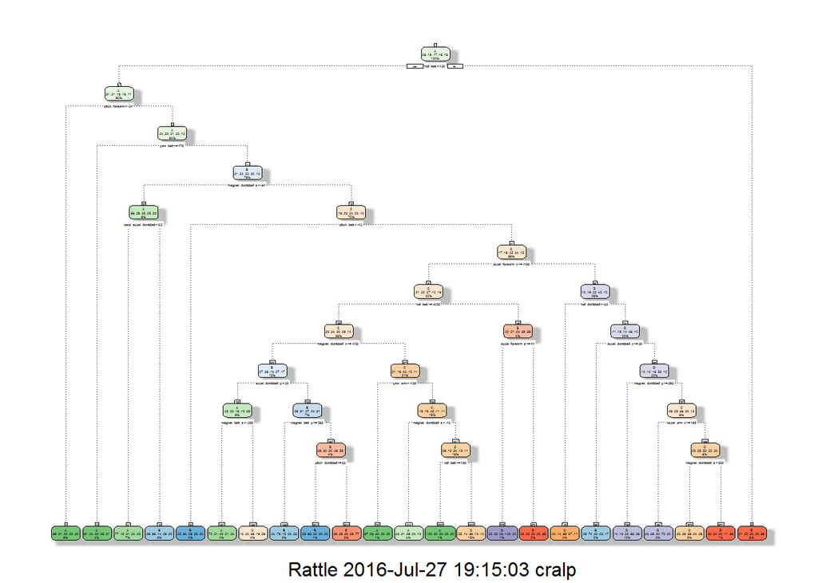

```r
set.seed(12345)
DT_model <- rpart(classe ~ ., data=train, method="class")
fancyRpartPlot(DT_model)
```

```r
DT_predict <- predict(DT_model, newdata=pre_test, type = "class")
confusionMatrix(DT_predict, pre_test$classe)
```

```
## Confusion Matrix and Statistics
##
##           Reference
## Prediction    A    B    C    D    E
##          A 1879  260   30   69   66
##          B   56  759   88   34   54
##          C  105  340 1226  354  234
##          D  155  132   23  807   57
##          E   37   27    1   22 1031
##
## Overall Statistics
##
##                Accuracy : 0.7267
##                  95% CI : (0.7167, 0.7366)
##     No Information Rate : 0.2845
##     P-Value [Acc > NIR] : < 2.2e-16
##
##                   Kappa : 0.6546
##  Mcnemar's Test P-Value : < 2.2e-16
##
## Statistics by Class:
##
##                      Class: A Class: B Class: C Class: D Class: E
## Sensitivity            0.8418  0.50000   0.8962   0.6275   0.7150
## Specificity            0.9243  0.96334   0.8405   0.9441   0.9864
## Pos Pred Value         0.8155  0.76589   0.5427   0.6874   0.9222
## Neg Pred Value         0.9363  0.88928   0.9746   0.9282   0.9389
## Prevalence             0.2845  0.19347   0.1744   0.1639   0.1838
## Detection Rate         0.2395  0.09674   0.1563   0.1029   0.1314
## Detection Prevalence   0.2937  0.12631   0.2879   0.1496   0.1425
## Balanced Accuracy      0.8831  0.73167   0.8684   0.7858   0.8507
```

Overall statistics from the Decision Tree model show a 73% accuracy with an out-of-sample error of 27%.

The Random Forest.

The Caret package has a training function that can be used with Random Forest to select the best model.

This training function tries several models and automatically selects the ‘best’ one. It also has cross-validation built in. However, we will still cross validate using the ‘pre_test’ data.

It may take several minutes to complete, which is one of this function’s negative aspects.

```r
library(randomForest, quietly = TRUE)
library(e1071, quietly = TRUE)

set.seed(12345)
control <- trainControl(method="cv", number=5, allowParallel=T, verbose=F)
RF_model <- train(classe ~ ., data=train, method='rf', trControl=control, verbose=F)

RF_predict <- predict(RF_model, newdata=train)
confusionMatrix(RF_predict, train$classe)
```

```
## Confusion Matrix and Statistics
##
##           Reference
## Prediction    A    B    C    D    E
##          A 3348    0    0    0    0
##          B    0 2279    0    0    0
##          C    0    0 2054    0    0
##          D    0    0    0 1930    0
##          E    0    0    0    0 2165
##
## Overall Statistics
##
##                Accuracy : 1
##                  95% CI : (0.9997, 1)
##     No Information Rate : 0.2843
##     P-Value [Acc > NIR] : < 2.2e-16
##
##                   Kappa : 1
##  Mcnemar's Test P-Value : NA
##
## Statistics by Class:
##
##                      Class: A Class: B Class: C Class: D Class: E
## Sensitivity            1.0000   1.0000   1.0000   1.0000   1.0000
## Specificity            1.0000   1.0000   1.0000   1.0000   1.0000
## Pos Pred Value         1.0000   1.0000   1.0000   1.0000   1.0000
## Neg Pred Value         1.0000   1.0000   1.0000   1.0000   1.0000
## Prevalence             0.2843   0.1935   0.1744   0.1639   0.1838
## Detection Rate         0.2843   0.1935   0.1744   0.1639   0.1838
## Detection Prevalence   0.2843   0.1935   0.1744   0.1639   0.1838
## Balanced Accuracy      1.0000   1.0000   1.0000   1.0000   1.0000
```

```r
RF_preT <- predict(RF_model, newdata=pre_test)
confusionMatrix(RF_preT, pre_test$classe)
```

```
## Confusion Matrix and Statistics
##
##           Reference
## Prediction    A    B    C    D    E
##          A 2228    9    0    0    0
##          B    4 1505    7    0    0
##          C    0    4 1360   21    4
##          D    0    0    1 1263    3
##          E    0    0    0    2 1435
##
## Overall Statistics
##
##                Accuracy : 0.993
##                  95% CI : (0.9909, 0.9947)
##     No Information Rate : 0.2845
##     P-Value [Acc > NIR] : < 2.2e-16
##
##                   Kappa : 0.9911
##  Mcnemar's Test P-Value : NA
##
## Statistics by Class:
##
##                      Class: A Class: B Class: C Class: D Class: E
## Sensitivity            0.9982   0.9914   0.9942   0.9821   0.9951
## Specificity            0.9984   0.9983   0.9955   0.9994   0.9997
## Pos Pred Value         0.9960   0.9927   0.9791   0.9968   0.9986
## Neg Pred Value         0.9993   0.9979   0.9988   0.9965   0.9989
## Prevalence             0.2845   0.1935   0.1744   0.1639   0.1838
## Detection Rate         0.2840   0.1918   0.1733   0.1610   0.1829
## Detection Prevalence   0.2851   0.1932   0.1770   0.1615   0.1832
## Balanced Accuracy      0.9983   0.9948   0.9948   0.9908   0.9974
```

Overall statistics from the Random Forest model show a 99% accuracy wwith an out-of-sample error of 1%.

## Summary

As you recall, the goal of this assigment was to develop a prediction that will predict the manner in which the exercises were done.

As was shown, the accuracy of the Decision Tree was 73%. The accuracy of the Random Forest model was 99%. Therefore, we will use the Random Forest method to predict the 20 test cases provided in the testing (tst) data.

## Final Prediction

```r
prediction <- predict(RF_model, newdata = tst)
prediction
```

```
##  [1] B A B A A E D B A A B C B A E E A B B B
## Levels: A B C D E
```